# Diagnosis of common skin cancers

Francois Collin

# 1 Background

- The present contains follow-up remarks for 2025-03-10 meeting
  - Maria Wei, Vince Wu, Francois Collin (Me)
- The remarks are procedural and may not apply, but they are based on my experience (mostly implementing the ideas of others) and have always resulted in a smooth path from concept to completion.
  - *Development and Validation of a Multiclass Model Defining Molecular Archetypes of Kidney Transplant Rejection* [1] is an example of a test which was developed and validated within 18 months. I was responsible for all design and analysis.
- The purpose of the 2025-03-10 meeting was to discuss some validation data and next steps, but I an not prepared to advise on the validation of a test I don’t fully understand. It may also be too early to start a formal validation process which can only begin after assay lock.
  - There are different notions of *validation*. The formal validation I am thinking about here is a validation report which will be filed with a regulatory agency.
  - “Validation” outside of the regulatory sphere of influence can mean anything from the tabulation of results without a formal analysis plan to analysis made according to a pre-specified plan that has been IRB approved and locked.
- Before validation begins, the Discovery Phase must be completed and the assay locked. The product of the Discovery Phase is a fully specified test:
  - how the test is carried out,
  - what are the sample analyzability conditions.
    - analyzability conditions, or inclusion criteria, come from the Data QC step.

# 2 Data QC - Sample and Run Validity Criteria

- **Before anything else happens**, the nature of the data used by the test being developed needs to be fully understood. A data QC procedure customized to the specific requirements of the test in development should be finalized and locked before being applied to runs that are part of the test development.
- The samples which are used to fit and validate a model are in many cases more impactful on the ultimate performance of an omic-based test than the selected model itself. It is therefore critically important to apply accurate, statistically sound Inclusion/Exclusion criteria when selecting samples for development and validation (FDA (2019) [2]).
- The success of this selection or identification process depends on having established a comprehensive QC procedure, customized to the specific needs of the test under consideration. The metrics in Melania et al. (2019) [3] to assess normalization can also be used for QC.
- Through analysis we can determine empirically which are the best metrics to use to identify which **specimens** and **analytical runs** are to be excluded. Inclusions and exclusions must be **pre-specified** as part of the locked procedure.
- This process must be fully documented.

## 2.1 On controls

- There are various sorts:
  - samples: positive and negative differential expression controls
  - features (miRNAS): stably expressed
  - synthetic miRNA spike-ins from commercial
- Control strategies can be implemenred such that various **truths** are built in every run and can be summuned for QC and normalization.

# 3 Model Selection

- The model selection process should be fully documented to ensure reproducibility.
- The criteria used to score models must be clearly stated as part of the documentation.
  - the model with the highest cross-validated accuracy estimate is **not necessarily the best** model to choose
    - many models may achieve the same accuracy after accounting for estimation error
    - other factors may be equally important:
      - interpretability
      - reproducibility
      - robustness to fitting set selection
      - in a multinomial context, not all error are equal
- In a multi-site context it is important to have a representative set of sites in the fitting set.

# 4 Assay Lock

A key component of a diagnostic test development process is Assay Lock.

- Validation only starts **after assay lock**.
- **Lock** means that the complete end-to-end procedure is frozen. It must occur *before* any validation begins
- The scope includes: specimen handling, instrument acquisition, and all data processing from the instruments output to the final result
- Every step must be **fully documented** at lock
  - this includes how the model was selected, all QC metrics and procedures, and acceptance/inclusion criteria.
- Any post-lock change constitutes a protocol deviation, and may invalidate subsequent validation data

# NCI IOM Guidelines

- Following several cases of **flawed products making it into the clinic**, the National Cancer Institute (NCI) requested that the Institute of Medicine (IOM) form a committee to *develop recommendations to clarify and improve the pathway from discovery to first use of omics-based tests in a clinical trials*.

> This report identifies best practices to enhance development, evaluation, and translation of omics-based tests while simultaneously reinforcing steps to ensure that these tests are appropriately assessed for scientific validity before they are used to guide patient treatment in clinical trials.
- Links to handy resources:
  - [White paper - Evolution of Translational Omics: Lessons Learned and the Path Forward](https://pubmed.ncbi.nlm.nih.gov/24872966/)
    - Guidelines for the Development of Omic Based Products
- Summary slides

# 5 Discovery Phase Workflows

For the discovery phase, there are three common development workflows.

## 5.1 Recommended Workflow

The recommended workflow is depicted in Figure 5.1.

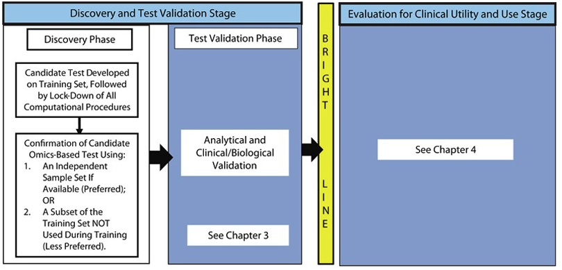

Figure 5.1: Omics-based test development process: recommended discovery phase

```r
CAPTION <-  paste(
c("Omics-based test development process: recommended discovery phase"))
```

### Note on the Confirmation Step

- In the flowchart in Figure 5.1, the recommended analysis steps includes a confirmation step which is run prior to any formal validation run.
- The confirmation step can provide added confidence in the expected results from the validation runs, or may indicate that some tweak to the test procedure is needed.
- The use of a confirmation step is highly recommended unless the test data has been extensively studied in the past and there would be little to learn from the results.
  - in my experience the need for a separate confirmation step can be assessed on a case by case basis.
  - if the training data are complex and representative of the target population, and the model well understood, and the out-of-fold error rate similar to the test subset error rate, then the risk of encountering unexpected and divergent results at validation is limit

## 5.2 No-Confirmation Workflow

- The No-Confirmation workflow is depicted in Figure 5.2.
- The No-Confirmation workflow can be risky, unless the test data are familiar.

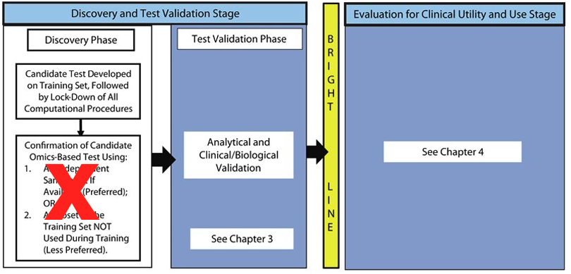

Figure 5.2: Omics-based test development process: no-confirmation discovery phase workflow

```r
CAPTION <-  paste(
c("Omics-based test development process: no-confirmation discovery phase workflow"))
```

## 5.3 Iterative Model Build Up Workflow

The Iterative Model Build Up workflow is depicted in Figure 5.3.

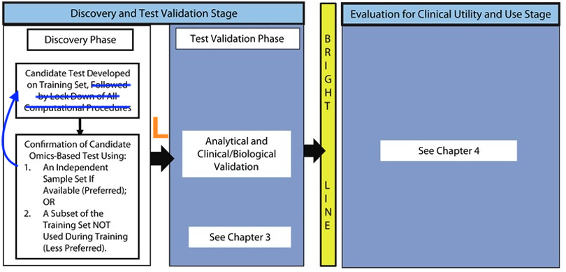

# 6 References

1.

Zhang, H., Haun, R.S., Collin, F., Cassol, C., Napier, J.O.H., Wilson, J., Hassen, S., Ararat, K., Boils, C., Messias, N., *et al.* (2024). [Development and validation of a multiclass model defining molecular archetypes of kidney transplant rejection: A large cohort study of the banff human organ transplant gene expression panel.](https://doi.org/10.1016/j.labinv.2023.100304) Lab Invest *104*, 100304.

3.

Molania, R., Gagnon-Bartsch, J.A., Dobrovic, A., and Speed, T.P. (2019). [A new normalization for nanostring nCounter gene expression data.](https://doi.org/10.1093/nar/gkz433) Nucleic Acids Res *47*, 6073–6083.